# DS400: Assignment V - GitHub and the ticketmaster.com API(R)

Sahra Pfeifer

2023-01-21

In this assignment, you will apply what you have learned about APIs and about version control with Git(Hub). First, you will acquire data about event venues using the API provided by ticketmaster.com. You will then use the geospatial data to visualize the extracted data on a map. Finally, you will repeat the same steps for a different country. It is further required that the entire project and its version history is documented in your personal GitHub repository.

```r
rm(list = ls())

setwd("C:/Users/Sahra/Desktop/M.Sc DS_WiSe1/DSPM/Assignment 5")
```

### Setting up a new GitHub repository

1. Register on github.com in case you have not done this already
2. Initialize a new public repository for this assignment on GitHub.
3. For the following exercises of this assignment, follow the standard Git workflow (i.e., pull the latest version of the project to your local computer, then stage, commit, and push all the modifications that you make throughout the project). Every logical programming step should be well documented on GitHub with a meaningful commit message, so that other people (e.g., your course instructor) can follow and understand the development history. You can do this either using Shell commands or a Git GUI of your choice.
4. In the HTML file that you submit, include the hyperlink to the project repository (e.g., https://github. com/yourUserName/yourProjectName)

[R repository](https://github.com/sahrapfeifer/Assignment_V_R.git)

### Getting to know the API

5. Visit the documentation website for the API provided by ticketmaster.com (see here). Familiarize yourself with the features and functionalities of the Ticketmaster Discovery API. Have a particular look at rate limits.

All API keys are issued with a default quota of 5000 API calls per day and rate limitation of 5 requests per second.

6. Whithin the scope of this assignment, you do not have to request your own API key. Instead retrieve a valid key from the API Explorer. This API key enables you to perform the GET requests needed throughout this assignment. Even though this API key is not secret per se (it is publicly visible on the API Explorer website), please comply to the common secrecy practices discussed in the lecture and the tutorial: Treat the API key as a secret token. Your API key should neither appear in the code that you are submitting nor in your public GitHub repository.

**Key stored in another script “API_Explorer_Key.R**

```r
# access the key from main script:
source("API_Explorer_Key.R")
```

### Interacting with the API - the basics

7. Perform a first GET request, that searches for event venues in Germany (countryCode = “DE”). Extract the content from the response object and inspect the resulting list. Describe what you can see.

```r
# load relevant packages:
library(jsonlite)
library(httr)
library(rlist)
library(tidyverse)
library(dplyr)
```

**Perform GET request**

```r
response <- GET("https://app.ticketmaster.com/discovery/v2/venues/?",
                query = list(apikey = TM_expl_key,
                             countryCode= "DE",
                             locale = "*")) %>% content()
```

8. Extract the name, the city, the postalCode and address, as well as the url and the longitude and latitude of the venues to a data frame. This data frame should have the following structure:

```r
## Rows: 20
## Columns: 7
## $ name <chr> "Gruenspan", "Huxleys Neue Welt", "Kleine Olympiahalle", "Z~
## $ city <chr> "Hamburg", "Berlin", "Munich", "Emmelshausen", "Mülheim", "~
## $ postalCode <dbl> 22767, 10967, 80809, 56281, 45479, 76646, 68766, 44263, 542~
## $ address <chr> "Grosse Freiheit 58", "Hasenheide 107 – 113", "Spiridon-Lou~
## $ url <chr> "http://www.ticketmaster.de/venue/287155", "http://www.tick~
## $ longitude <dbl> 9.958075, 13.421380, 11.550920, 7.556560, 6.874710, 8.59908~
## $ latitude <dbl> 53.55188, 52.48639, 48.17543, 50.15544, 51.42778, 49.12692,~
```

**Extract the seven columns with a Base R approach**

```r
library(tidyverse)
list <- lapply(response$`_embedded`$venues, unlist)

# Ensure all list entries have values for the same keys:
keys <- unique(unlist(lapply(list, names)))
keys
```

```
##  [1] "name"                            "type"
##  [3] "id"                              "test"
##  [5] "url"                             "locale"
##  [7] "images.ratio"                    "images.url"
##  [9] "images.width"                    "images.height"
## [11] "images.fallback"                 "postalCode"
## [13] "timezone"                        "city.name"
## [15] "country.name"                    "country.countryCode"
## [17] "address.line1"                   "location.longitude"
## [19] "location.latitude"               "markets.name"
## [21] "markets.id"                      "dmas.id"
## [23] "boxOfficeInfo.phoneNumberDetail" "upcomingEvents._total"
## [25] "upcomingEvents.mfx-de"           "upcomingEvents._filtered"
## [27] "ada.adaPhones"                   "ada.adaCustomCopy"
## [29] "ada.adaHours"                    "_links.self.href"
```

```r
# Fill missing key entries with NA:
list <- lapply(list, function(x) x[match(keys, names(x))])

# use rbind to combine into data.frame:
venues_op <- do.call(rbind.data.frame, list)
colnames(venues_op) <- keys

# extract desired columns
cols <-  c("name","postalCode","url","city.name","address.line1",
           "location.longitude","location.latitude") #in desired order,

venues_op <- venues_op[cols]
#venues_op for "one page"

# rename columns:
library(data.table)
setnames(venues_op, old = c("city.name", "address.line1",
                            "location.longitude", "location.latitude"),
         new = c("city","adress","longitude","latitude"))

# convert to numeric:
colsnum <- c("postalCode","longitude","latitude")

venues_op[colsnum] <- sapply(venues_op[colsnum], as.numeric)
```

**Have a look on the data and print first 10 observations**

```r
glimpse(venues_op)
```

```
## Rows: 20
## Columns: 7
## $ name       <chr> "Grosse Freiheit 36", "Gruenspan", "Huxleys Neue Welt", "Ze~
## $ postalCode <dbl> 22767, 22767, 10967, 56281, 45479, 76646, 68766, 44263, 542~
## $ url        <chr> "http://www.ticketmaster.de/venue/287636", "http://www.tick~
## $ city       <chr> "Hamburg", "Hamburg", "Berlin", "Emmelshausen", "Mülheim", ~
## $ adress     <chr> "Grosse Freiheit 36", "Grosse Freiheit 58", "Hasenheide 107~
## $ longitude  <dbl> 9.957905, 9.958075, 13.421380, 7.556560, 6.874710, 8.599080~
## $ latitude   <dbl> 53.55119, 53.55188, 52.48639, 50.15544, 51.42778, 49.12692,~
```

```r
print(head(venues_op,10))
```

```
##                        name postalCode
## 1        Grosse Freiheit 36      22767
## 2                 Gruenspan      22767
## 3         Huxleys Neue Welt      10967
## 4           Zentrum am Park      56281
## 5  Stadthalle (Theatersaal)      45479
## 6             Schlossgarten      76646
## 7                Stadthalle      68766
## 8                       FZW      44263
## 9               Arena Trier      54292
## 10            Eissporthalle      87700
##                                                                                         url
## 1                                                   http://www.ticketmaster.de/venue/287636
## 2                                                   http://www.ticketmaster.de/venue/287155
## 3                                                   http://www.ticketmaster.de/venue/286842
```

[output cut: 18 more lines]

### Interacting with the API - advanced

9. Have a closer look at the list element named page. Did your GET request from exercise (7) return all event locations in Germany? Obviously not - there are of course much more venues in Germany than those contained in this list. Your GET request only yielded the first results page containing the first 20 out of several thousands of venues. Check the API documentation under the section Venue Search. How can you request the venues from the remaining results pages? Iterate over the results pages and perform GET requests for all venues in Germany. After each iteration, extract the seven variables name, city, postalCode, address, url, longitude, and latitude. Join the information in one large data frame. Print the first 10 rows and the shape of the resulting data frame. The resulting data frame should look something like this (note that the exact number of search results may have changed since this document has been last modified):

```r
## Rows: 12,671
## Columns: 7
## $ name <chr> "Gruenspan", "Huxleys Neue Welt", "Kleine Olympiahalle", "Z~
## $ city <chr> "Hamburg", "Berlin", "Munich", "Emmelshausen", "Mülheim", "~
## $ postalCode <dbl> 22767, 10967, 80809, 56281, 45479, 76646, 68766, 44263, 542~
## $ address <chr> "Grosse Freiheit 58", "Hasenheide 107 – 113", "Spiridon-Lou~
## $ url <chr> "http://www.ticketmaster.de/venue/287155", "http://www.tick~
## $ longitude <dbl> 9.958075, 13.421380, 11.550920, 7.556560, 6.874710, 8.59908~
## $ latitude <dbl> 53.55188, 52.48639, 48.17543, 50.15544, 51.42778, 49.12692,~
```

```r
# store number of totalElements in numeric object:
n <- as.numeric(response[["page"]][["totalElements"]])
n
```

```
## [1] 12935
```

**Define a function**

```r
# define a function to request the data and return a list of results
worker <- function(page){
  # enforce a rate limit
  Sys.sleep(.2)
  # call the API and get the respective page
  res_venues <- GET("https://app.ticketmaster.com/discovery/v2/venues/?",
                    query = list(apikey = TM_expl_key,
                                 countryCode= "DE",
                                 page = page,
                                 locale = "*"))

  content(res_venues)$`_embedded`

}
```

**Adjustments of the dataframe**

```r
# rename columns:
setnames(venues_all, old = c("city.name", "address.line1",
                             "location.longitude", "location.latitude"),
         new = c("city","adress","longitude","latitude"))

# convert to numeric:
colsnum <- c("postalCode","longitude","latitude")

venues_all[colsnum] <- sapply(venues_all[colsnum], as.numeric)
```

**Print first 10 observations**

```r
# have a glimpse on the data:
glimpse(venues_all)
```

```
## Rows: 12,695
## Columns: 7
## $ name       <chr> "Mies-van-der-Rohe-Schule", "Willingen (Upland) Open Air", ~
## $ postalCode <dbl> 52068, 34508, 20359, 20539, 51063, 21109, 6406, 44145, 7017~
## $ url        <chr> "https://www.ticketmaster.de/venue/mies-van-der-rohe-schule~
## $ city       <chr> "Aachen", "Willingen", "Hamburg", "Hamburg", "Cologne", "Ha~
## $ adress     <chr> "Neuköllner Str. 17", "Vor den Weiden", "Spielbudenplatz 21~
## $ longitude  <dbl> 6.12308, 8.60622, 9.96438, 9.96426, 7.01283, 10.00251, 11.7~
## $ latitude   <dbl> 50.78956, 51.29061, 53.54941, 53.54923, 50.96650, 53.49572,~
```

```r
# print first 10 observations:
print(head(venues_all, 10))
```

```
## # A tibble: 10 x 7
##    name                        postalCode url       city  adress longi~1 latit~2
##    <chr>                            <dbl> <chr>     <chr> <chr>    <dbl>   <dbl>
##  1 Mies-van-der-Rohe-Schule         52068 https://~ Aach~ Neukö~    6.12    50.8
##  2 Willingen (Upland) Open Air      34508 https://~ Will~ Vor d~    8.61    51.3
##  3 Häkken (Klubhaus St. Pauli)      20359 https://~ Hamb~ Spiel~    9.96    53.5
##  4 Bahnhof Pauli                    20539 https://~ Hamb~ Spiel~    9.96    53.5
##  5 Club Volta                       51063 https://~ Colo~ Schan~    7.01    51.0
##  6 edel-optics.de Arena             21109 https://~ Hamb~ Kurt-~   10.0     53.5
##  7 Kurhaus                           6406 https://~ Bern~ Solba~   11.7     51.8
##  8 Junkyard                         44145 https://~ Dort~ Schlä~    7.47    51.5
##  9 Kulturquartier Proton            70173 https://~ Stut~ König~    9.18    48.8
## 10 Aula am Berliner Ring            40789 https://~ Monh~ Berli~    6.89    51.1
## # ... with abbreviated variable names 1: longitude, 2: latitude
```

Some of the values got lost for a reason…

### Visualizing the extracted data

10. Below, you can find code that produces a map of Germany. Add points to the map indicating the locations of the event venues across Germany.

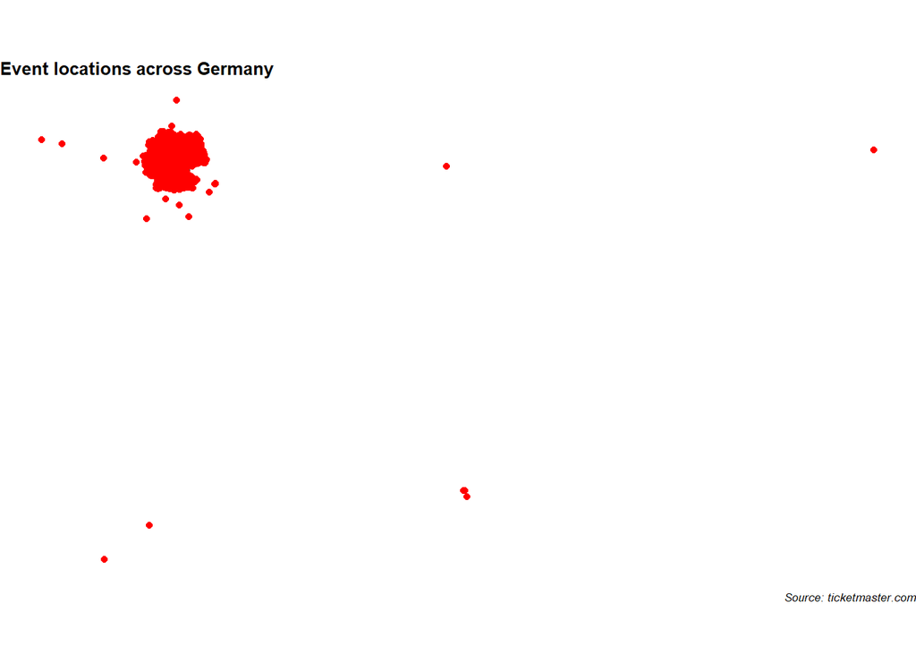

```r
ggplot() +
  borders("world", "Germany", colour = "black", fill = "grey90") +
  theme_void() +
  coord_quickmap() +
  geom_point(data = venues_all,
             aes(x=longitude, y=latitude), colour="red",
             fill="red") +
  labs(title = "Event locations across Germany",
       caption = "Source: ticketmaster.com") +
  theme(title = element_text(size=8, face='bold'),
        plot.caption = element_text(face = "italic"))
```

11. You will find that some coordinates lie way beyond the German borders and can be assumed to be faulty. Set coordinate values to NA where the value of longitude is outside the range (5.866, 15.042) or where the value of latitude is outside the range (47.270, 55.059) (these coordinate ranges have been derived from the extreme points of Germany as listed on Wikipedia (see here). For extreme points of other countries, see here).

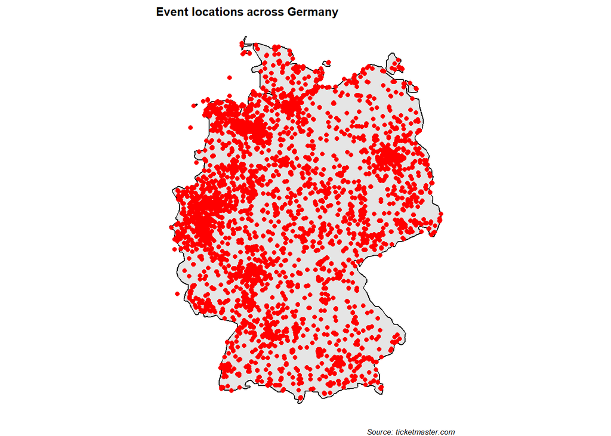

```r
ggplot() +
  borders("world", "Germany", colour = "black", fill = "grey90") +
  theme_void() +
  coord_quickmap() +
  geom_point(data = venues_all,
             # in plot directly set NA for all values outside long/lat range of Germany
             aes(x=ifelse(longitude %between% c(5.866, 15.042),
                          longitude, NA),
                 y=ifelse(latitude %between% c(47.270, 55.059),
                          latitude, NA)), colour="red",
             fill="red") +
  labs(title = "Event locations across Germany",
       caption = "Source: ticketmaster.com") +
  theme(title = element_text(size=8, face='bold'),
        plot.caption = element_text(face = "italic"))
```

### Event locations in other countries

12. Repeat exercises (9)–(11) for another European country of your choice. (Hint: Clean code pays off! If you have coded the exercises efficiently, only very few adaptions need to be made.)

**(9) Exercise**

```r
# Check content response:
response_ES <- GET("https://app.ticketmaster.com/discovery/v2/venues/?",
                  query = list(apikey = TM_expl_key,
                               countryCode= "ES",
                               locale = "*")) %>% content()
```

**number of all venues in Spain:**

```r
n_ES <- as.numeric(response_ES[["page"]][["totalElements"]])
n_ES
```

```
## [1] 3312
```

**set countryCode in function to “ES”**:

```r
worker <- function(page){
    # enforce a rate limit
    Sys.sleep(.2)
    # call the API and get the respective page
    res_venues <- GET("https://app.ticketmaster.com/discovery/v2/venues/",
                      query = list(apikey = TM_expl_key,
                                   countryCode= "ES",
                                   page = page,
                                   # for all locations "*"
                                   locale = "*"))

    # return the search items
    content(res_venues)$`_embedded`

}
```

**Adjustments**

```r
# rename columns:
setnames(venues_ES, old = c("city.name", "address.line1",
                                "location.longitude", "location.latitude"),
         new = c("city","adress","longitude","latitude"))

# convert to numeric:
venues_ES[colsnum] <- sapply(venues_ES[colsnum], as.numeric)
```

**Print first 10 observations of venues in Spain**:

```r
glimpse(venues_ES)
```

```
## Rows: 3,252
## Columns: 7
## $ name       <chr> "Parc de Can Zam", "Monte do Gozo", "Antiga Fàbrica Estrell~
## $ postalCode <dbl> 8924, 15820, 8025, 28005, 28008, 8038, 8005, 28042, 12200, ~
## $ url        <chr> "https://www.ticketmaster.es/venue/parc-de-can-zam-santa-co~
## $ city       <chr> "Santa Coloma de Gramenet", "Santiago de Compostela", "Barc~
## $ adress     <chr> NA, "Rúa do Gozo, 18", "Carrer del Rosselló, 515", "Calle d~
## $ longitude  <dbl> 2.194230, -8.500140, 2.177990, -3.710690, -3.718810, 2.1556~
## $ latitude   <dbl> 41.45632, 42.88672, 41.40941, 40.40880, 40.42089, 41.36476,~
```

```r
print(head(venues_ES,10))
```

```
## # A tibble: 10 x 7
##    name                             postalC~1 url   city  adress longi~2 latit~3
##    <chr>                                <dbl> <chr> <chr> <chr>    <dbl>   <dbl>
##  1 Parc de Can Zam                       8924 http~ Sant~ <NA>     2.19     41.5
##  2 Monte do Gozo                        15820 http~ Sant~ Rúa d~  -8.50     42.9
##  3 Antiga Fàbrica Estrella Damm          8025 http~ Barc~ Carre~   2.18     41.4
##  4 Sala Shoko                           28005 http~ Madr~ Calle~  -3.71     40.4
##  5 Warner Music Station Prínc. Pío      28008 http~ Madr~ Cuest~  -3.72     40.4
##  6 Estadi Olímpic Lluis Companys         8038 http~ Barc~ Passe~   2.16     41.4
##  7 La Nau                                8005 http~ Barc~ Carre~   2.20     41.4
##  8 Palacio Municipal - IFEMA MADRID     28042 http~ Madr~ Av. d~  -3.62     40.5
##  9 Recinto Multiusos de Onda            12200 http~ Onda  C/ To~  -0.267    40.0
## 10 La Marina                            46024 http~ Vale~ C. Ma~  -0.324    39.5
## # ... with abbreviated variable names 1: postalCode, 2: longitude, 3: latitude
```

**(10) Exercise** * Plot the results**

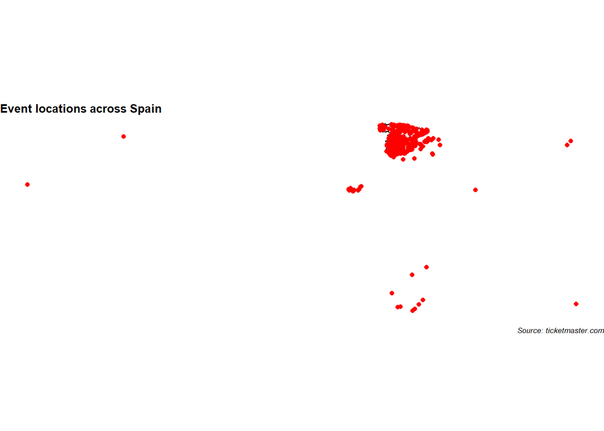

```r
ggplot() +
  borders("world", "Spain", colour = "black", fill = "grey90") +
  theme_void() +
  coord_quickmap() +
  geom_point(data = venues_ES,
             aes(x=longitude, y=latitude), colour="red",
             fill="red") +
  labs(title = "Event locations across Spain",
       caption = "Source: ticketmaster.com") +
  theme(title = element_text(size=8, face='bold'),
        plot.caption = element_text(face = "italic"))
```

**(11) Exercise**

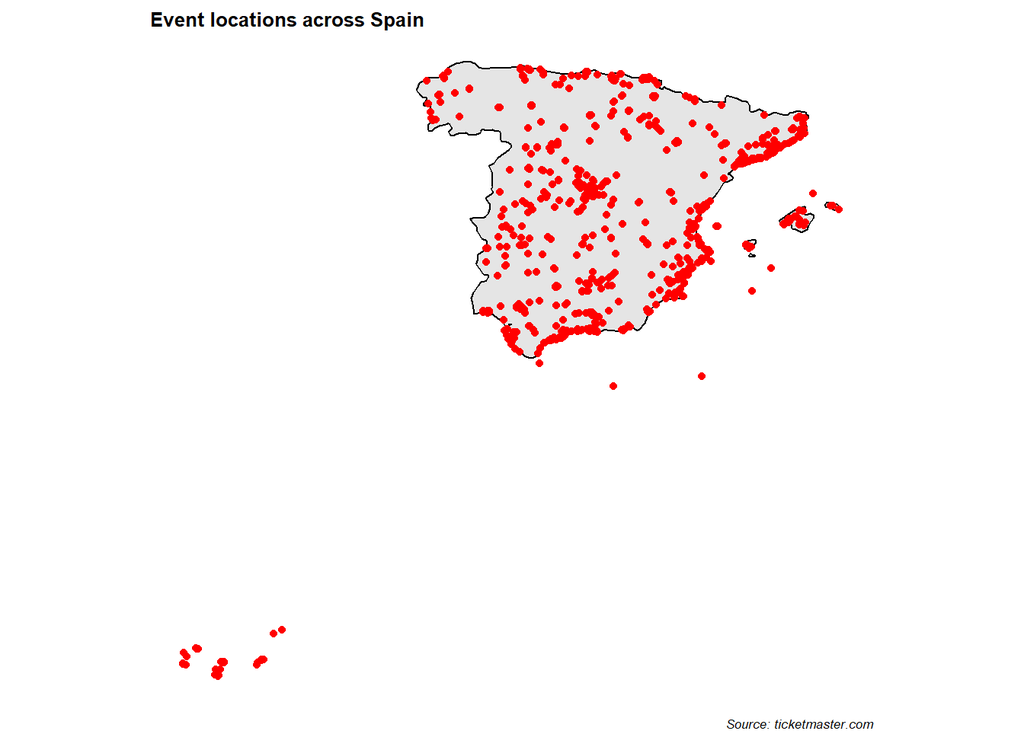

```r
ggplot() +
  borders("world", "Spain", colour = "black", fill = "grey90") +
  theme_void() +
  coord_quickmap() +
  geom_point(data = venues_ES,
             # in plot directly set NA for all values outside long/lat range of Germany
             aes(x=ifelse(longitude %between% c(-17.934,4.289),
                          longitude, NA),
                 y=ifelse(latitude %between% c(27.633, 43.738),
                          latitude, NA)), colour="red",
             fill="red") +
  labs(title = "Event locations across Spain",
       caption = "Source: ticketmaster.com") +
  theme(title = element_text(size=8, face='bold'),
        plot.caption = element_text(face = "italic"))
```